# Jamba Overview

James M. Ward

2026-07-26

# Jamba Overview

Jamba is intended to contain JAM base functions, to be re-used during analysis, and by other R packages. Functions are broadly divided into categories.

## Efficient alphanumeric sort

The `mixedSort()`, `mixedSortDF()` functions are designed for “genes”, “chromosomes”, and “versions”, with alphanumeric sorting. For example: * gene `"ACTA2"` before `"ACTA10"` * micro-RNA `"hsa-miR-21"` before `"hsa-miR-100"` * chromosome `"chr2"` before `"chr10"`

It is fast enough for most large dataset operations, not unreasonably slower than `base::sort()`, and much faster than alternative approaches.

- `mixedSort()` - alphanumeric sort.
- `mixedSortDF()` - sort `data.frame` (`tibble`, `matrix`, `DataFrame`, etc.)
- `mixedSorts()` - sort `list` of vectors, vectorized for speed boost.

Example:

|  | miRNA | sort_rank | mixedSort_rank |
| --- | --- | --- | --- |
| 2 | ABCA2 | 2 | 1 |
| 1 | ABCA12 | 1 | 2 |
| 3 | miR-1 | 3 | 3 |
| 6 | miR-1a | 6 | 4 |
| 7 | miR-1b | 7 | 5 |
| 8 | miR-2 | 8 | 6 |
| 4 | miR-12 | 4 | 7 |
| 9 | miR-22 | 9 | 8 |
| 5 | miR-122 | 5 | 9 |

## Plot functions

### `plotSmoothScatter()`

A common problem when visualizing extremely large datasets is how to display thousands of datapoints while indicating the amount of overlap of those points. The “overplotting” problem.

The R `graphics::smoothScatter()` function provides an adequate drop-in replacement for most uses of `plot()`, and `plotSmoothScatter()` applies some enhanced defaults.

The customizations use “bin” to define the bin size, and “bw” to define the 2D kernel density bandwidth. The bandwidth defines the detail of the “carpet”, the point landscape if you will. The bin size defines how many pixels are used to render this carpet. Typically the bin size is related to the graphics device resolution. However, bandwidth should be related to relative detail in the data.

Adjustments are easiest with arguments: * `binpi` - bins per inch * `bwpi` bandwidth per inch

Running `plotSmoothScatter()` with `doTest=TRUE` produces some visual comparison with default `smoothScatter()`.

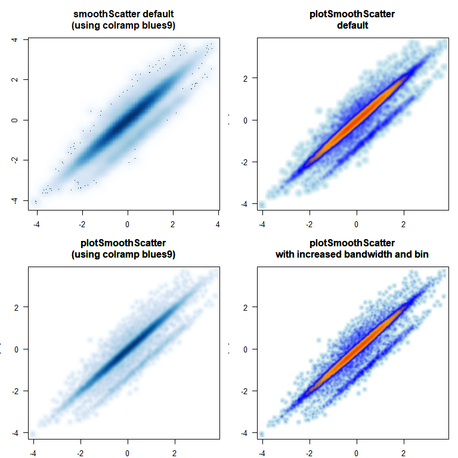

```r
plotSmoothScatter(doTest=TRUE);
```

### `imageByColors()`

The `imageByColors()` function is intended to take a matrix or data.frame that already contains colors in each cell. It optionally displays cell labels when supplied.

Cell labels are grouped to display one unique label per repeated label, using the function `breaksByVector()` to group labels.

This function is particularly useful to simplify labels in a large table of repeated values, for example in experiment design.

Here, we define a simple data.frame composed of colors, then use the data.frame to label itself:

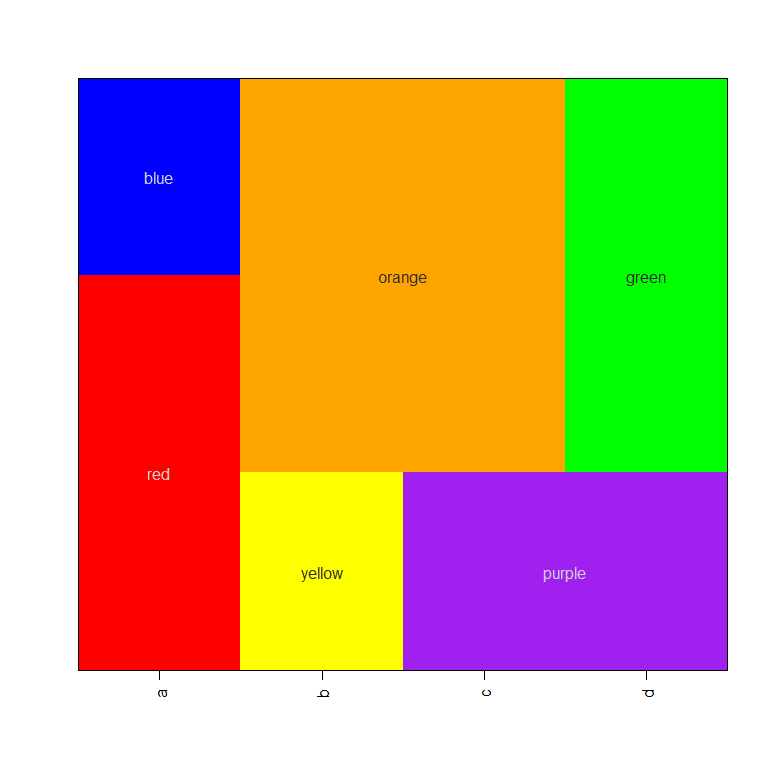

```r
a1 <- c("red","blue")[c(1,1,2)];
b1 <- c("yellow","orange")[c(1,2,2)];
c1 <- c("purple","orange")[c(1,2,2)];
d1 <- c("purple","green")[c(1,2,2)];
df1 <- data.frame(a=a1, b=b1, c=c1, d=d1);
imageByColors(df1, cellnote=df1);
```

Labels can be independently rotated and resized, an arbitrary example is shown below:

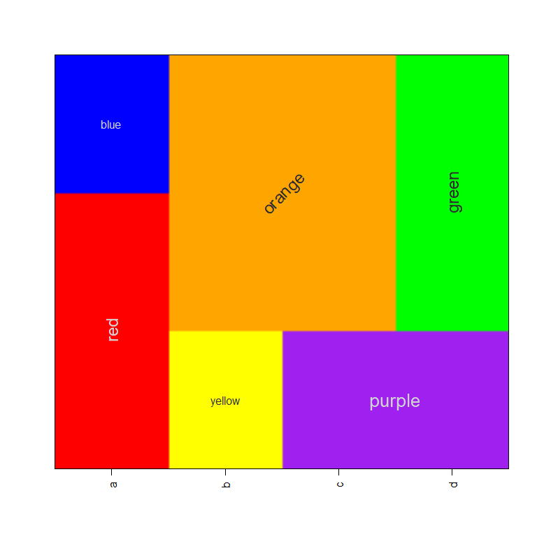

```r
imageByColors(df1,
   cellnote=df1,
   useRaster=TRUE,
   #adjBy="column",
   cexCellnote=list(c(1.5,1.5,1),
      c(1,1.5),
      c(1.6,1.2),
      c(1.6,1.5)),
   srtCellnote=list(c(90,0,0),
      c(0,45),
      c(0,0,0),
      c(0,90,0)));
```

### Axis label functions

There are several useful axis labeling functions.

For log-transformed data, `minorLogTicksAxis()` is a flexible function to help deal with different transforms. It enables “offset”, commonly used with `log2(1 + x)`, but now enables using any offset, e.g. `log2(0.5 + x)`. Axis labels use integer values, accounting for the offset.

The `logBase` can be customized, can be properly labeled when showing `log10(P-value)`. When showing log2 fold changes, it accepts negative values and flips the sign accordingly.

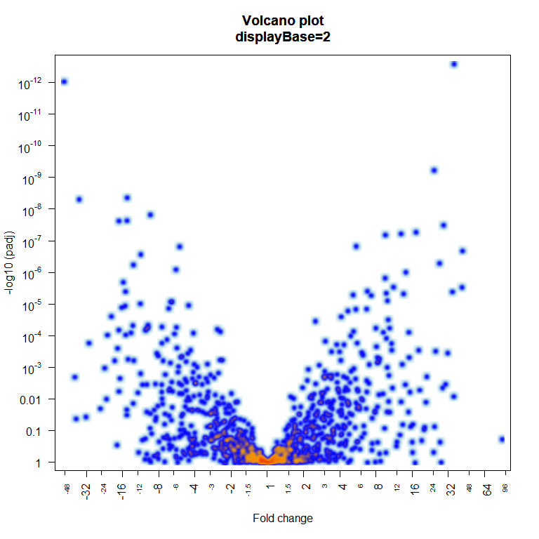

```r
# example showing volcano plot features
set.seed(123);
n <- 1000;
vdf <- data.frame(lfc=rnorm(n) * 2)
vdf$`-log10 (padj)` <- abs(vdf$lfc) * abs(rnorm(n))
plotSmoothScatter(vdf, xaxt="n", yaxt="n", xlab="Fold change",
   main="Volcano plot\ndisplayBase=2")
logFoldAxis(1)
pvalueAxis(2)
```

### `plotPolygonDensity()`

`plotPolygonDensity()` is a light wrapper around two functions: `hist()` and `density()`. However, it makes two other options convenient:

- Transform the x-axis with either `log10(1 + x)` or `sqrt()`, use `xScale=c("default", "log10", "sqrt")`.
- Display multiple panels for each column of a numeric matrix.
- See also: `plotRidges()` - a ggridges alternative.

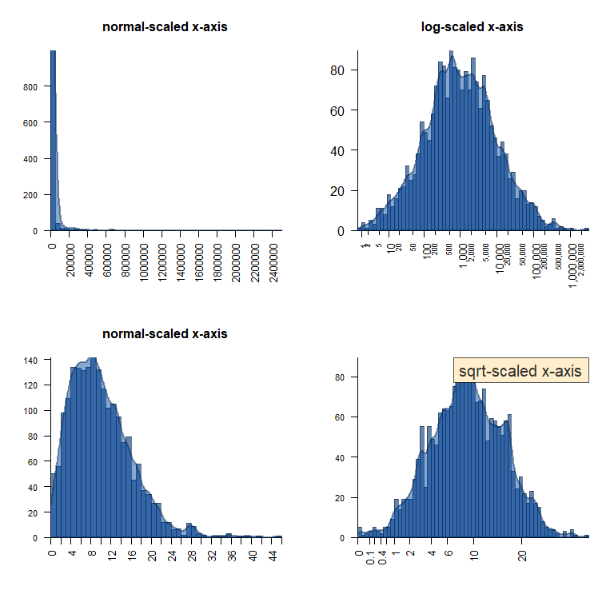

```r
withr::with_par(list("mar"=c(6, 4, 4, 2), "mfrow"=c(2, 2)), {
   withr::local_options(list("scipen"=7));
set.seed(123);
plotPolygonDensity(10^(3+rnorm(2000)),
   breaks=50,
   cex.axis=1,
   main="normal-scaled x-axis");
plotPolygonDensity(10^(3+rnorm(2000)),
   log="x",
   breaks=50,
   main="log-scaled x-axis");
plotPolygonDensity((3+rnorm(2000))^2,
   cex.axis=1,
   breaks=50,
   main="normal-scaled x-axis");
plotPolygonDensity((3+rnorm(2000))^2,
   cex.axis=1,
   xScale="sqrt",
   breaks=50,
   main="");
drawLabels(preset="topright",
   txt="sqrt-scaled x-axis",
   labelCex=1.5)
})
```

### `drawLabels()`

`drawLabels()` is aimed at base R graphics, and provides a quick way to add a label to a plot. The argument `preset` is used to place the label relative to the sides and corners of the plot.

Shown below `text_fn=jamba::shadowText` will enable shadow text output.

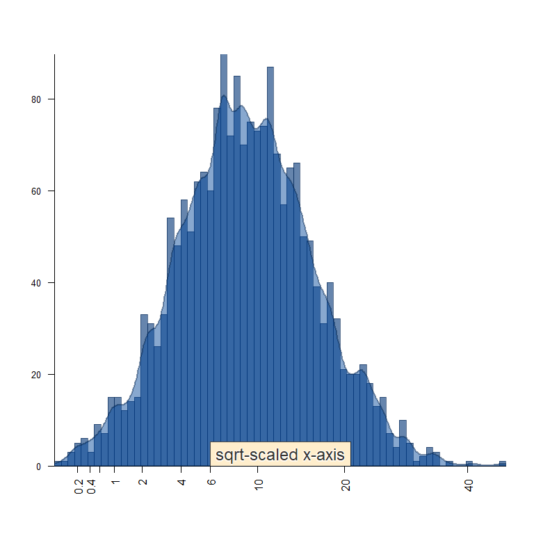

```r
par("mfrow"=c(1,1))
plotPolygonDensity((3+rnorm(2000))^2,
   cex.axis=1,
   xScale="sqrt",
   breaks=50,
   main="");
drawLabels(preset="bottom",
   txt="sqrt-scaled x-axis",
   text_fn=jamba::shadowText,
   labelCex=1.5)
```

## Colors

For me, color plays a big role in my daily work, both in how I use R, and the figures and visualizations I produce during data analysis.

Another Jam package `colorjam` focuses on defining categorical colors in an extensible manner.

### `getColorRamp()`

- `getColorRamp()` is a workhorse of several other functions and workflows.
  - It makes convenient the job of obtaining a color ramp (aka a color palette, or color gradient). It interfaces with `RColorBrewer` and `viridisLite` for color palette names, and allows some useful extensions.
  - It accepts suffix `"_r"` to reverse color order, `RColorBrewer` palette `"RdBu"` is reversed with `"RdBu_r"`. Red should be the high color in a heatmap - “heat”, so “RdBu_r” is recommended.

### `printDebug()`

- `printDebug()` is present in every Jam function, used when `verbose=TRUE` to follow the processing steps. Of course it uses color.
- `printDebugHtml()` is used for RMarkdown output, use the chunk option `results='asis'` so the HTML is displayed properly.
- `printDebugI()` is an alternative that “inverts” the color, using the color as background, with contrasting text color on top.
- When a vector is provided, its values are delimited with `sep`, and each value is “dithered” with the same color with lighter/darker pattern for visual distinction.
- Each element is assigned a color recycled from `fgText`, and can be customized.

```r
printDebugHtml("printDebugHtml(): ",
  "Output is colorized: ",
  head(LETTERS, 8))
```

(13:13:50) 26Jul2026: printDebugHtml(): Output is colorized: A,B,C,D,E,F,G,H

```r
withr::with_options(list(jam.htmlOut=TRUE, jam.comment=FALSE), {
  printDebugHtml(c("printDebug() using withr::with_options(): "),
    c("Output should be colorized: "),
    head(LETTERS, 8));
})
```

(13:13:51) 26Jul2026: printDebug() using withr::with_options(): Output should be colorized: A,B,C,D,E,F,G,H

### `showColors()`

- `showColors()` displays a color ramp, or `list` of color ramps, or a `function` as defined by `circlize::colorRamp2()`. (Amazing function by the way.)

### Other color functions

- `warpRamp()` is used with argument `lens` in other functions, and can warp the colors for more contrast. It even handles divergent colors, keeping the middle color intact.
- `rainbow2()` is a very simple drop-in replacement for `rainbow()`, which adds alternating contrast to adjacent colors. A better option is `colorjam::rainbowJam()` but `rainbow2()` is a simple option until colorjam is on CRAN.

```r
showColors(list(
   Reds=getColorRamp("Reds"),
   RdBu=getColorRamp("RdBu"),
   RdBu_r=getColorRamp("RdBu_r"),
   `RdBu_r, lens=5`=warpRamp(getColorRamp("RdBu_r"), lens=5),
   `RdBu_r, lens=-5`=warpRamp(getColorRamp("RdBu_r"), lens=-5),
   `rainbow2(15)`=rainbow2(15)
   ));
```

[figure not shown]

## Console functions

### `setPrompt()`

`setPrompt()` is a convenience function for R console and RStudio work, it creates a colorized R prompt with useful info: * project name * R version * Process ID (PID). The PID is useful in case *ahem* the R session runs wild.

Ultimately, it helps answer the question “What am I working on?”

```r
setPrompt("jambaVignette");
# {jambaVignette}-R-3.6.0_10789>
```

### `jargs()`

Jam `args()`.

- Aligns arguments, one per row
- Allows pattern search
- Optionally sorts by argument name
- Colorized in the R console

```r
# all args
jargs(plotSmoothScatter)
```

```
#>                 x = ,
#>                 y = NULL,
#>              bwpi = 50,
#>             binpi = 50,
#>        bandwidthN = NULL,
#>              nbin = NULL,
#>            expand = c(0.04, 0.04),
#>       transFactor = 0.25,
#>    transformation = function( x ) x^transFactor,
#>              xlim = NULL,
#>              ylim = NULL,
#>              xlab = NULL,
#>              ylab = NULL,
#>          nrpoints = 0,
#>           colramp = c("white", "lightblue", "blue", "orange", "orangered2"),
#>               col = "black",
#>            doTest = FALSE,
#>    fillBackground = TRUE,
#>          naAction = c("remove", "floor0", "floor1"),
#>              xaxt = "s",
#>              yaxt = "s",
#>               add = FALSE,
#>               asp = NULL,
#> applyRangeCeiling = TRUE,
#>         useRaster = TRUE,
#>           verbose = FALSE,
#>               ... =
```

```r
# args with "y" in the name
jargs(plotSmoothScatter, "^y")
```

```
#>    y = NULL,
#> ylim = NULL,
#> ylab = NULL,
#> yaxt = "s"
```

### `sdim()` and `ssdim()`

These functions apply `dim()` to a list, or list of lists. They recognize other S4 object types, and special types like `igraph` and Bioconductor objects.

It returns either `data.frame` of dimensions, or `list` of `data.frame`, which can be easily parsed and reviewed.

```r
L <- list(LETTERS=LETTERS,
   letters=letters,
   lettersDF=data.frame(LETTERS, letters));
sdim(L);
```

|  | rows | cols | class |
| --- | --- | --- | --- |
| LETTERS | 26 |  | character |
| letters | 26 |  | character |
| lettersDF | 26 | 2 | data.frame |

```r
L2 <- list(List1=L,
   List2=L);

sdim(L2);
```

|  | rows | class |
| --- | --- | --- |
| List1 | 3 | list |
| List2 | 3 | list |

```r
ssdim(L2)
```

```
#> $List1
#>           rows cols      class
#> LETTERS     26       character
#> letters     26       character
#> lettersDF   26    2 data.frame
#>
#> $List2
#>           rows cols      class
#> LETTERS     26       character
#> letters     26       character
#> lettersDF   26    2 data.frame
```

## Excel functions

### `writeOpenxlsx()`

`writeOpenxlsx()` is a convenient wrapper for the amazing `openxlsx`, to automate numeric formatting, column color, font size, text alignment. When saving to Excel, you want all the details to look pretty, and to be usable without having to configure it later.

It has presets for certain data types, with default numeric formatting, and conditional color-coding by default: * P-values * fold change, log fold change * numeric values * integer values * highlight columns (bold font)

It configures some defaults: * column headers have filtering enabled * striped column and header colors * freeze pane and row to keep the header visible * column widths * word wrap, or not * header row height * categorical colors when defined

Some nice extras: * save one or more worksheets to the same file * optionally include rownames

### `readOpenxlsx()`

`readOpenxlsx()` is convenient for reading all worksheets in an Excel file, and returns data without mangling the column headers. It returns a `list` of `data.frame` objects.

## Convenience

### `vigrep()`, `provigrep()`, `igrep()`, `igrepHas()`

Quick custom `base::grep()` for case-insensitive, or value-returning work.

- `vigrep()` - extends grep to use `value=TRUE` and `ignore.case=TRUE`
- `igrep()` - extends grep to use `ignore.case=TRUE`, case-insensitive matching.
- `provigrep()` - progressive pattern matching, returning entries in the order they match a vector of patterns. Super useful.
- `igrepHas()` - extends `igrep()` to return `TRUE` or `FALSE`, convenient for `if()` statements.

### `gsubOrdered()`

`gsubOrdered()` is an extension to `gsub()` that preserves factor order of the input data, creating new ordered factor levels using the same `gsub()` replacement. Much more useful than you might think!

### `pasteByRow()` and `pasteByRowOrdered()`

`pasteByRow()` is a lightweight by efficient method for combining multiple columns into one character string. There are other approaches, however this function is among the fastest, especially 10000 rows or more, and allows “ignoring” empty cells in the output, and trimming leading/trailing blanks.

`pasteByRowOrdered()` is an extension of `pasteByRow()` that also maintains factor level order of each column. Again, super useful to make labels that honor factor level order, for example with experimental designs.

```r
a1 <- factor(c("mutant", "control")[c(1,1,2)],
   levels=c("control", "mutant"));
b1 <- factor(c("vehicle", "treated")[c(2,1,1)],
   levels=c("vehicle", "treated"));
d1 <- c("purple","green")[c(1,2,2)];
df2 <- data.frame(a=a1, b=b1, d=d1);
df2;
```

| a | b | d |
| --- | --- | --- |
| mutant | treated | purple |
| mutant | vehicle | green |
| control | vehicle | green |

```r
pasteByRow(df2);
```

```
#>                       1                       2                       3
#> "mutant_treated_purple"  "mutant_vehicle_green" "control_vehicle_green"
```

```r
pasteByRowOrdered(df2);
```

```
#>                     1                     2                     3
#> mutant_treated_purple  mutant_vehicle_green control_vehicle_green
#> Levels: control_vehicle_green mutant_vehicle_green mutant_treated_purple
```

```r
df3 <- data.frame(df2,
   pasteByRowOrdered=pasteByRowOrdered(df2));
mixedSortDF(df3, byCols="pasteByRowOrdered")
```

|  | a | b | d | pasteByRowOrdered |
| --- | --- | --- | --- | --- |
| 3 | control | vehicle | green | control_vehicle_green |
| 2 | mutant | vehicle | green | mutant_vehicle_green |
| 1 | mutant | treated | purple | mutant_treated_purple |

### `makeNames()`, `nameVector()`, `nameVectorN()`

Create unique names with controlled versioning options. The `base::make.unique()` is great, but sometimes you need to control the output.

- `makeNames()` returns unique names, by default for duplicated values it uses the suffix style `_v1`, `_v2`, `_v3`. The suffix can be controlled, whether to add a suffix to singlet entries, what number to start with, etc.
- `nameVector()` is similar to `setNames()` except that it secretly runs `makeNames()`, and when only provided with a vector, the vector is used to define names. Named vectors are convenient with `lapply()` type list functions, because names are used in the returned `list`.

`nameVectorN()` creates a named vector of the vector names, useful with `lapply()` when you need to know the element name in the function call.

```r
x <- rep(head(letters, 4), c(2,4,1,5));
x;
```

```
#>  [1] "a" "a" "b" "b" "b" "b" "c" "d" "d" "d" "d" "d"
```

```r
makeNames(x);
```

```
#>  [1] "a_v1" "a_v2" "b_v1" "b_v2" "b_v3" "b_v4" "c"    "d_v1" "d_v2" "d_v3"
#> [11] "d_v4" "d_v5"
```

```r
nameVector(x);
```

```
#> a_v1 a_v2 b_v1 b_v2 b_v3 b_v4    c d_v1 d_v2 d_v3 d_v4 d_v5
#>  "a"  "a"  "b"  "b"  "b"  "b"  "c"  "d"  "d"  "d"  "d"  "d"
```

```r
y <- nameVector(x);
nameVectorN(y);
```

```
#>   a_v1   a_v2   b_v1   b_v2   b_v3   b_v4      c   d_v1   d_v2   d_v3   d_v4
#> "a_v1" "a_v2" "b_v1" "b_v2" "b_v3" "b_v4"    "c" "d_v1" "d_v2" "d_v3" "d_v4"
#>   d_v5
#> "d_v5"
```

```r
lapply(nameVectorN(head(y)), function(i){
   i
})
```

```
#> $a_v1
#> [1] "a_v1"
#>
#> $a_v2
#> [1] "a_v2"
#>
#> $b_v1
#> [1] "b_v1"
#>
#> $b_v2
#> [1] "b_v2"
#>
#> $b_v3
#> [1] "b_v3"
#>
#> $b_v4
#> [1] "b_v4"
```

### `cPaste()`, `cPasteSU()`, `cPasteU()`

`cPaste()` “concatenate-paste”, takes a `list` and combines each vectors using a delimiter. It is among the fastest methods (at the time), partly by using `S4Vectors::unstrsplit()` if available. (Kudos Herve Pages!)

- `cPasteU()` calls `unique()` for each vector (vectorized).
- `cPasteS()` applies `mixedSort()` to each vector (vectorized).
- `cPasteSU()` spplies sort and unique.

These functions are very useful when operating on a list of gene symbols. For example, a vector of 500,000 assay probe names may be converted to a list of gene symbols, with some assay probe names associated with multiple gene symbols. The function `cPasteSU()` combines gene symbols with delimiter `","`, after sorting and making values unique.

It is also useful with gene-pathway data, where biological pathways are associated with a long list of gene symbols.

```r
set.seed(123);
x <- lapply(seq_len(6), function(i){
   paste0("Gene",
      sample(LETTERS,
         sample(c(1,1,2,5,9), 1),
         replace=TRUE));
});
cPaste(x);
```

```
#> [1] "GeneN,GeneC" "GeneR"       "GeneE,GeneT" "GeneZ"       "GeneE,GeneS"
#> [6] "GeneY,GeneY"
```

```r
cPasteU(x);
```

```
#> [1] "GeneN,GeneC" "GeneR"       "GeneE,GeneT" "GeneZ"       "GeneE,GeneS"
#> [6] "GeneY"
```

```r
cPasteSU(x);
```

```
#> [1] "GeneC,GeneN" "GeneR"       "GeneE,GeneT" "GeneZ"       "GeneE,GeneS"
#> [6] "GeneY"
```

```r
data.frame(cPaste=cPaste(x),
   cPasteU=cPasteU(x),
   cPasteSU=cPasteSU(x))
```

| cPaste | cPasteU | cPasteSU |
| --- | --- | --- |
| GeneN,GeneC | GeneN,GeneC | GeneC,GeneN |
| GeneR | GeneR | GeneR |
| GeneE,GeneT | GeneE,GeneT | GeneE,GeneT |
| GeneZ | GeneZ | GeneZ |
| GeneE,GeneS | GeneE,GeneS | GeneE,GeneS |
| GeneY,GeneY | GeneY | GeneY |

## RMarkdown Colored Tables

### `kable_coloring()`

- `kable_coloring()` - applies categorical colors to `kable()` output using `kableExtra::kable()`. It also applies a contrasting text color.

```r
expt_df <- data.frame(
  Sample_ID="",
  Treatment=rep(c("Vehicle", "Dex"), each=6),
  Genotype=rep(c("Wildtype", "Knockout"), each=3),
  Rep=paste0("rep", c(1:3)))
expt_df$Sample_ID <- pasteByRow(expt_df[, 2:4])

# define colors
colorSub <- c(Vehicle="palegoldenrod",
  Dex="navy",
  Wildtype="gold",
  Knockout="firebrick",
  nameVector(color2gradient("grey48", n=3, dex=10), rep("rep", 3), suffix=""),
  nameVector(
    color2gradient(n=3,
      c("goldenrod1", "indianred3", "royalblue3", "darkorchid4")),
    expt_df$Sample_ID))
if (requireNamespace("kableExtra", quietly=FALSE)) {
   kbl <- kable_coloring(
     expt_df,
     caption="Experiment design table showing categorical color assignment.",
     colorSub)
}
```